# Hector_SLR_comparison

CH

3/1/2021

### Problem -

where are we getting SLR estimates from for the TD? I dropped the ball in thinking about SLR estimates. I was under the impression that IEc was going to have them but never thought of where we would get them from. IEc decided not to be linked to 1 model (i.e. BRICK) and so they rebinned their damages based on SLR. So now we need trajectories of SLR.

Can we simply use Hector’s SLR estimates instead of getting BRICK up and running for the TD? I recall Hector’s SLR pretty outdated. is it?

### Compare Hector’s SLR output with observations and IPCC projections.

Hector uses a simple relationship between temperature to global mean sea level rise.

Martin Vermeer and Stefan Rahmstorf  
PNAS December 22, 2009 106 (51) 21527-21532;  
https://doi.org/10.1073/pnas.0907765106

How well does this compare to observations and to IPCC projections?

Start with comparison to observations. Observations run out to 2013. (RCPs shift to future in 2006)

Church and White observations relative to 1990

### Plot up observations and RCPs

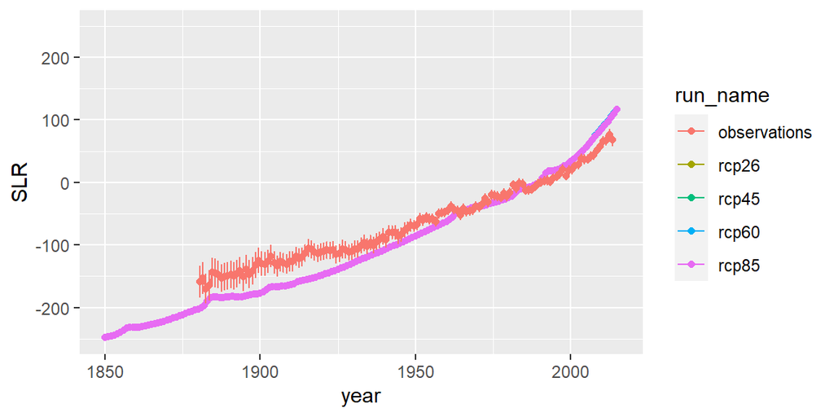

### Comparison to figure in IPCC AR5 WGI_AR5_Fig13-27

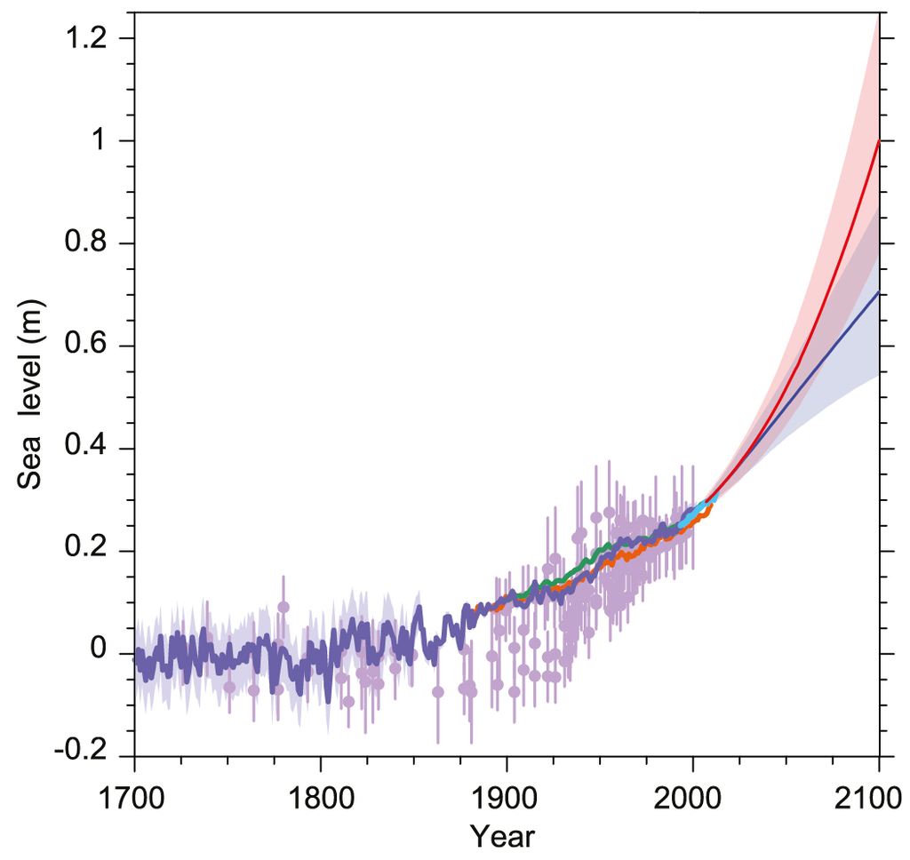

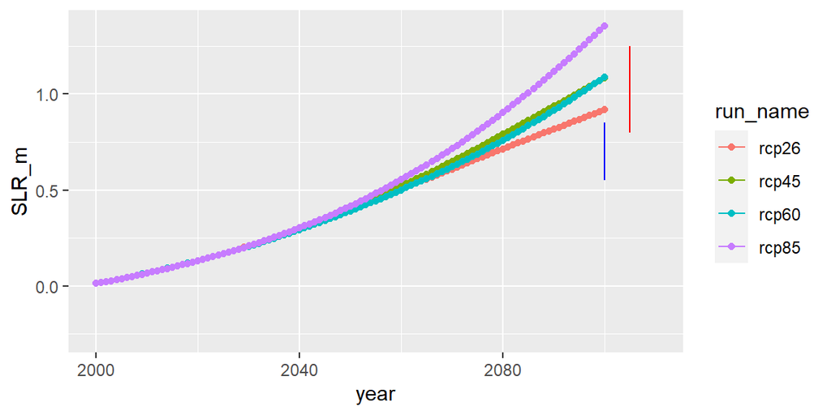

### NOTES

Hector matches observations well but runs higher than IPCC estimates. Especially on the lower end (RCP26). RCP45 and RCP60 no real difference between scenarios (a bit confused by why)

Now what: 1. use Hector as is. we are focusing on showcasing the capability not necessarily results. We could mention that hector runs high and our damages maybe overestimated.  
2. use temp to SLR conversion that IEc used in the past.  
3. get BRICK running on my end or IEc’s end. I downloaded the code and ran through the tutorial but no tutorial as to how to run a new scenario. I can reach out to my contacts to potentially help with this. Klaus Keller, Ryan Sriver etc. - are pretty helpful and responsive. I emailed the developer (tony wong) a month ago but no word back - can re-ping him.  
4. ask PNNL for a quick turn around using the version of coupled Hector BRICK. This was run at PNNL for OTAQ.  
5. run MAGICC instead of Hector.  
6. does FAIR calculate SLR? I don’t know off hand - need to dig into code.